# EDLD 653 Midterm

Author

Kat Vrotsos

```r
# load libraries
library(tidyverse)
library(here)
library(rio)
library(glue)
library(janitor)
library(gapr)
library(fs)
```

## Part A: Data

The following function downloads data from the Oregon Department of education website on the number of students who scored in each performance category on the statewide assessment by race/ethnicity for every school in the state. It takes one argument, `year`, which must be a two digit integer from 15 to 18 (representing the 2014-15 to 2017-18 school years). It actually won’t work on later years because the file structure changed and I wanted to keep the function simple.

```r
download_file <- function(year) {
  link <- glue::glue("https://www.oregon.gov/ode/educator-resources/assessment/TestResults20{year}/pagr_schools_ela_raceethnicity_{year-1}{year}.xlsx")
  rio::import(link, setclass = "tibble", na = c("-", "--", "*"))
}
```

### 1. Use the function above to download **all** of the data from the 2014-15 to 2017-18 school years and bind it into a single data frame, **using a single function** (i.e., one line of code).

```r
# map onto years from 15 to 18 using download_file function
full_data <- map_dfr(15:18, ~download_file(.x))

# make sure data matches example
print(full_data, n = 10)
```

```
# A tibble: 110,943 × 21
   `Academic Year` `District ID` District   `School ID` School           Subject
   <chr>                   <dbl> <chr>            <dbl> <chr>            <chr>
 1 2014-2015                2063 Adel SD 21         498 Adel Elementary… Englis…
 2 2014-2015                2063 Adel SD 21         498 Adel Elementary… Englis…
 3 2014-2015                2063 Adel SD 21         498 Adel Elementary… Englis…
 4 2014-2015                2063 Adel SD 21         498 Adel Elementary… Englis…
 5 2014-2015                2063 Adel SD 21         498 Adel Elementary… Englis…
 6 2014-2015                2063 Adel SD 21         498 Adel Elementary… Englis…
 7 2014-2015                2063 Adel SD 21         498 Adel Elementary… Englis…
 8 2014-2015                2063 Adel SD 21         498 Adel Elementary… Englis…
 9 2014-2015                2063 Adel SD 21         498 Adel Elementary… Englis…
10 2014-2015                2063 Adel SD 21         498 Adel Elementary… Englis…
# ℹ 110,933 more rows
# ℹ 15 more variables: `Student Group` <chr>, `Grade Level` <chr>,
#   `Number Proficient (Level 3 or 4)` <chr>,
#   `Percent Proficient (Level 3 or 4)` <chr>, `Number Level 4` <dbl>,
#   `Percent Level 4` <dbl>, `Number Level 3` <dbl>, `Percent Level 3` <dbl>,
#   `Number Level 2` <dbl>, `Percent Level 2` <dbl>, `Number Level 1` <dbl>,
#   `Percent Level 1` <dbl>, `Number of Participants` <dbl>, …
```

#### Conduct some basic data cleaning to make your data file look like the following.

- Filter for only student groups coded as `"White"` or `"Hispanic/Latino"`.
- Select variables related to the number of students in each of the levels (1 through 4), and **not** percentages or combined levels.
- Remove any row that has missing data in any of the *n* variables

```r
clean_data <- full_data |>
  filter(`Student Group` == 'White' | `Student Group` == 'Hispanic/Latino') |>
  drop_na(`Number Level 1`, `Number Level 2`, `Number Level 3`, `Number Level 4`) |>
  pivot_longer(
    cols = starts_with('Number Level'),
    names_to = 'level',
    values_to = 'n',
    names_prefix = 'Number Level '
  ) |>
  select(
    academic_year = `Academic Year`,
    district = District,
    school = School,
    student_group = `Student Group`,
    grade_level = `Grade Level`,
    level,
    n
  )

# check if data matches
print(clean_data, n = 10)
```

```
# A tibble: 90,576 × 7
   academic_year district     school       student_group grade_level level     n
   <chr>         <chr>        <chr>        <chr>         <chr>       <chr> <dbl>
 1 2014-2015     Adrian SD 61 Adrian Elem… Hispanic/Lat… Grade 3     4         1
 2 2014-2015     Adrian SD 61 Adrian Elem… Hispanic/Lat… Grade 3     3         2
 3 2014-2015     Adrian SD 61 Adrian Elem… Hispanic/Lat… Grade 3     2         1
 4 2014-2015     Adrian SD 61 Adrian Elem… Hispanic/Lat… Grade 3     1         2
 5 2014-2015     Adrian SD 61 Adrian Elem… Hispanic/Lat… Grade 6     4         0
 6 2014-2015     Adrian SD 61 Adrian Elem… Hispanic/Lat… Grade 6     3         2
 7 2014-2015     Adrian SD 61 Adrian Elem… Hispanic/Lat… Grade 6     2         3
 8 2014-2015     Adrian SD 61 Adrian Elem… Hispanic/Lat… Grade 6     1         2
 9 2014-2015     Adrian SD 61 Adrian Elem… Hispanic/Lat… Grade 7     4         0
10 2014-2015     Adrian SD 61 Adrian Elem… Hispanic/Lat… Grade 7     3         2
# ℹ 90,566 more rows
```

```r
# level is descending instead of ascending but the numbers for level and n match
# referenced old notes from the first data class (:
```

### 2. Sum the *n* across grades and school for each district within each academic year, student group, and level. Calculate the number of schools (unique schools listed) for each district. Also move your data to a wider format where the student groups become new columns, filled by the district n. Remove districts that did not report numbers for one or both student groups (i.e., drop missing data from the new columns).

```r
grouped <- clean_data |>
  group_by(district) |>
  mutate(n_schools = n_distinct(school)) |>
  ungroup() |>
  group_by(academic_year, district, student_group, level) |>
   summarize(
    district_n = sum(n),
    n_schools = first(n_schools),
    .groups = "drop") |>
  pivot_wider(
    names_from = student_group,
    values_from = district_n
  ) |>
  clean_names() |>
  drop_na(hispanic_latino, white)

print(grouped, n = 10)
```

```
# A tibble: 1,948 × 6
   academic_year district     level n_schools hispanic_latino white
   <chr>         <chr>        <chr>     <int>           <dbl> <dbl>
 1 2014-2015     Adrian SD 61 1             2               6     8
 2 2014-2015     Adrian SD 61 2             2               6    17
 3 2014-2015     Adrian SD 61 3             2               6    23
 4 2014-2015     Adrian SD 61 4             2               1    22
 5 2014-2015     Amity SD 4J  1             3              19    75
 6 2014-2015     Amity SD 4J  2             3              26    86
 7 2014-2015     Amity SD 4J  3             3              14   101
 8 2014-2015     Amity SD 4J  4             3               3    31
 9 2014-2015     Ashland SD 5 1             6              18    76
10 2014-2015     Ashland SD 5 2             6              24   141
# ℹ 1,938 more rows
```

```r
# had to look up how to change the column names without spaces (janitor package), why my code wasn't working initially (== instead of = in summarize and did not drop groups), and how to keep n_schools in the final tibble: https://share.google/aimode/sUKslPl6AuEpXefR1
```

## **Part B: Achievement Disparities**

Please install the [`{gapr}`](https://github.com/datalorax/gapr) package using the following code:

```r
#remotes::install_github("datalorax/gapr")
```

The `{gapr}` package includes a function, `estimate_v()`, which estimates the average difference between two distributions in terms of an effect size when the only data available are counts within bins (for more information, see [Ho & Reardon, 2012](https://journals.sagepub.com/doi/10.3102/1076998611411918)). The nice thing about this approach is that we’re able to obtain the effect size of average differences in achievement between two groups of students as if we had the full, student level data even though we just have counts within bins (performance levels).

The `estimate_v()` function takes 3 arguments in the following order:

1. the data frame including the counts for each group,
2. a character string stating the name of the column with the counts for the reference group, and
3. a character string stating the name of the column with the counts for the focal group.

To estimate the average achievement difference between students coded Hispanic/Latino versus White for the first school district in the first year in our data, we would run the following:

```r
library(gapr)
grouped[1:4, ] |> # data source - just first four rows for first district
  estimate_v("white", "hispanic_latino") # columns for reference/focal groups
```

```
Warning: Using `size` aesthetic for lines was deprecated in ggplot2 3.4.0.
ℹ Please use `linewidth` instead.
ℹ The deprecated feature was likely used in the RJafroc package.
  Please report the issue to the authors.
```

```
        auc          v       v_se
1 0.2824054 -0.8141778 0.07283486
```

We can see that students coded Hispanic/Latino scored, on average, about 0.81 standard deviations *below* students coded White within this school district for this year.

### **1.** Estimate the average achievement differences in terms of an effect size for every school district in the state that reported data on both student groups (i.e., using the data we created above), for each academic year. Conduct this analysis twice, once using `group_by() |> nest()` and `map()` and once using `nest_by() |> summarize()`.

Note, on my computer these took about 1 minute per analysis. It will likely take a bit longer for you, but shouldn’t take *too* long. You may get a warning. Just go ahead and ignore that for now.

```r
# using group_by() |> nest() and map()
b1_map <- grouped |>
  group_by(district, academic_year) |>
  nest() |>
  mutate(achieve_diff_groupby = map(data, ~estimate_v(.x, "white", "hispanic_latino")))
```

[output not shown]

```r
# using nest_by() |> summarize()
b1_summarize <- grouped |>
  nest_by(district, academic_year) |>
  summarize(achieve_diff_nestby = list(estimate_v(data, "white", "hispanic_latino")))
```

[output not shown]

```
`summarise()` has converted the output from a rowwise data frame to a grouped
data frame.
ℹ Summaries were computed rowwise.
ℹ Output is grouped by district and academic_year.
ℹ Use `summarise(.groups = "keep")` to silence this message.
```

### 2. Reproduce the following plot to confirm that the estimates are equivalent across methods.

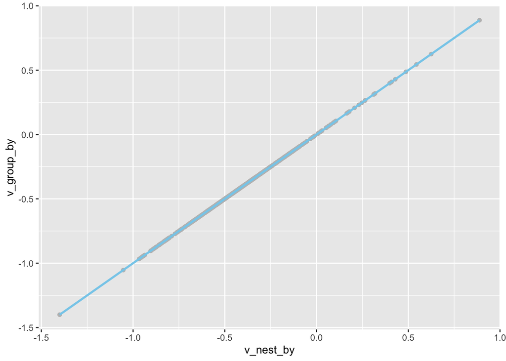

```r
# join data
compare_nested <- left_join(b1_map, b1_summarize, by = c("district", "academic_year"))

# get v from both
compare <- compare_nested |>
  mutate(
    v_group_by = as.numeric(map(achieve_diff_groupby, ~.x[['v']])),
    v_nest_by = as.numeric(map(achieve_diff_nestby, ~.x[['v']]))
  )

# reproduce the plot

compare_plot <- compare |>
  ggplot(aes(v_nest_by, v_group_by)) +
  geom_point(color = 'grey') +
  geom_smooth(color = 'skyblue')
compare_plot
```

### 3. The plot below shows the achievement difference estimates for one school district across years. Produce a similar plot to the below for each of the first 100 school districts. Once you’ve created all the plots, **reproduce them again using an alternative method**. Make sure you don’t miss the caption noting the number of schools in the district.

**Hint**: You need to select unique *districts*. You may want to try something like the following:

```r
dists <- unique(compare$district)[1:100]

dists_100 <- compare |>
  filter(district %in% dists)
```

```r
# not working as intended
# get n_schools out of data for ggplot caption - need first value since it's the same across years
#dists_100_n <- dists_100 |>
  #group_by(district) |>
  #mutate(n_schools_dist = map_dbl(data, ~.x[['n_schools']][1]))
```

```r
# nest_by() method

#dists_nest <- dists_100_n |>
    #ungroup() |>
    #nest_by(district) |>
   # mutate(
     # plot = list(
      #  ggplot(data, aes(academic_year, v_group_by)) +
       # geom_line(color = 'grey') +
       # geom_point() +
        #guides(fill = 'none') +
       # labs(
        #  title = glue('Achievement Gap Estimates: {district}'),
         # subtitle = ,
         # x = 'School year',
        #  y = 'Average achievement difference (SD units)',
         ## caption =
       # ) +
        #  theme_minimal()
  #  )
 # )

#dists_nest$plot[7]
```

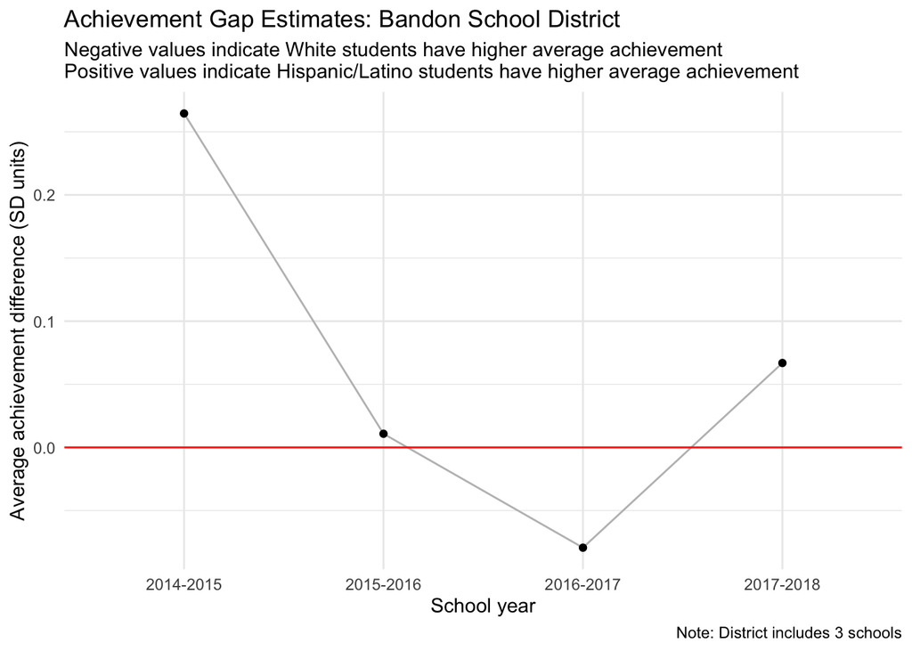

```r
# got very stuck and tried using Google AI again by plugging in my previous code https://share.google/aimode/QxWKhzsgk97ETZqD6
## still struggling to get se for the error bars to work without breaking anything - gave up on it after over an hour

library(stringr)

# Clean the district names first
compare_cleaned <- compare |>
  ungroup() |>
  mutate(district = str_replace(district, "(.*) SD.*", "\\1 School District"))

# 1. Identify the first 100 unique cleaned districts
dists <- unique(compare_cleaned$district)[1:100]

# 2. Method 1: Using nest_by and rowwise
plots_nestby <- compare_cleaned |>
  filter(district %in% dists) |>
  # Ensure n_schools is attached (using district name or a join)
  left_join(grouped |>
              mutate(district = str_replace(district, "(.*) SD.*", "\\1 School District")) |>
              select(district, n_schools) |>
              distinct(),
            by = "district") |>
  nest_by(district, n_schools) |>
  mutate(plot = list(
    ggplot(data, aes(academic_year, v_nest_by, group = 1)) +
      geom_line(color = "grey") +
      geom_point() +
      #geom_errorbar() +
      geom_hline(yintercept = 0, color = "red") +
      labs(title = glue::glue("Achievement Gap Estimates: {district}"),
           subtitle = "Negative values indicate White students have higher average achievement\nPositive values indicate Hispanic/Latino students have higher average achievement",
           x = "School year",
           y = "Average achievement difference (SD units)",
           caption = glue::glue("Note: District includes {n_schools} schools")) +
      theme_minimal()
  ))

plots_nestby$plot[[7]]
```

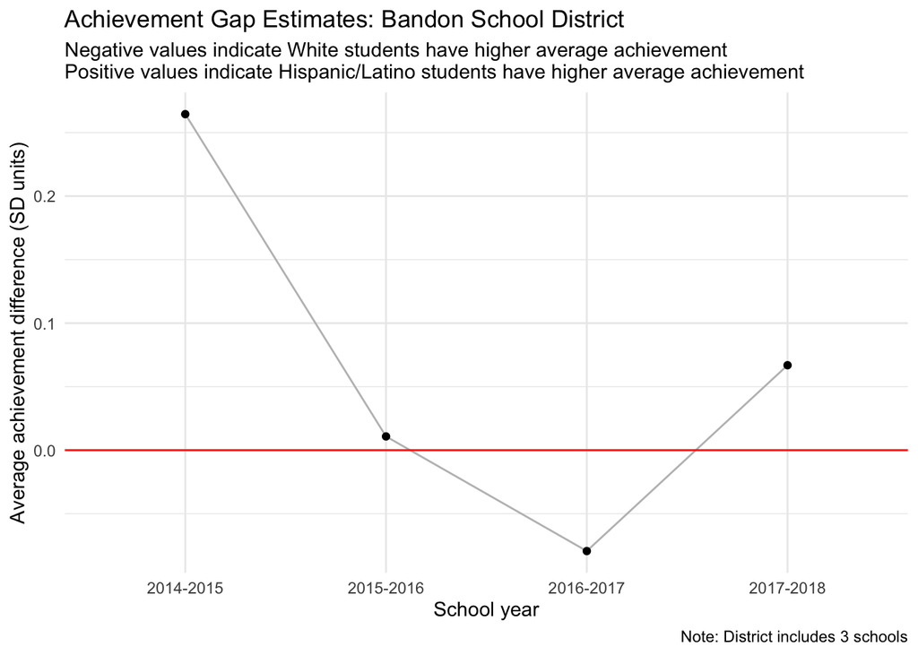

```r
# rowwise method

plots_rowwise <- compare_cleaned |>
  filter(district %in% dists) |>
  left_join(
    grouped |>
      mutate(district = str_replace(district, "SD.*", "School District")) |>
      select(district, n_schools) |>
      distinct(),
    by = "district"
  ) |>
  nest(data = -c(district, n_schools)) |>
  rowwise(district, n_schools) |>
  mutate(plot = list(
    ggplot(data, aes(academic_year, v_nest_by, group = 1)) +
      geom_line(color = "grey") +
      geom_point() +
      #geom_errorbar() +
      geom_hline(yintercept = 0, color = "red") +
      labs(title = glue::glue("Achievement Gap Estimates: {district}"),
           subtitle = "Negative values indicate White students have higher average achievement\nPositive values indicate Hispanic/Latino students have higher average achievement",
           x = "School year",
           y = "Average achievement difference (SD units)",
           caption = glue::glue("Note: District includes {n_schools} schools")) +
      theme_minimal()
  ))

plots_rowwise$plot[[7]]
```

### 4. Save the plots into a “plots” directory. Make sure the file names are meaningful.

**HINTS**

- You don’t have to use a loop to create the file names (maybe give `{glue}` a try? Otherwise `paste` or `paste0` will work fine).
- When working with the code, limit the number of plots you’re saving to, say, the first five to make sure it works before running it on all plots.

```r
# make a directory
dir_create(here("plots", "nest_by"))

# create file paths - separate objects
files <- str_replace_all(
  tolower(plots_nestby$district),
  " ",
  "-"
)
paths <- here("plots", "nest_by", glue("{files}.png"))
paths
```

```
  [1] "/Users/kat/Desktop/EDLD 653 Functional Programming/Midterm/EDLD_653_midterm/plots/nest_by/adrian-school-district.png"
  [2] "/Users/kat/Desktop/EDLD 653 Functional Programming/Midterm/EDLD_653_midterm/plots/nest_by/amity-school-district.png"
  [3] "/Users/kat/Desktop/EDLD 653 Functional Programming/Midterm/EDLD_653_midterm/plots/nest_by/ashland-school-district.png"
  [4] "/Users/kat/Desktop/EDLD 653 Functional Programming/Midterm/EDLD_653_midterm/plots/nest_by/astoria-school-district.png"
  [5] "/Users/kat/Desktop/EDLD 653 Functional Programming/Midterm/EDLD_653_midterm/plots/nest_by/athena-weston-school-district.png"
  [6] "/Users/kat/Desktop/EDLD 653 Functional Programming/Midterm/EDLD_653_midterm/plots/nest_by/baker-school-district.png"
  [7] "/Users/kat/Desktop/EDLD 653 Functional Programming/Midterm/EDLD_653_midterm/plots/nest_by/bandon-school-district.png"
  [8] "/Users/kat/Desktop/EDLD 653 Functional Programming/Midterm/EDLD_653_midterm/plots/nest_by/banks-school-district.png"
  [9] "/Users/kat/Desktop/EDLD 653 Functional Programming/Midterm/EDLD_653_midterm/plots/nest_by/beaverton-school-district.png"
 [10] "/Users/kat/Desktop/EDLD 653 Functional Programming/Midterm/EDLD_653_midterm/plots/nest_by/bend-lapine-administrative-school-district.png"
 [11] "/Users/kat/Desktop/EDLD 653 Functional Programming/Midterm/EDLD_653_midterm/plots/nest_by/bethel-school-district.png"
 [12] "/Users/kat/Desktop/EDLD 653 Functional Programming/Midterm/EDLD_653_midterm/plots/nest_by/brookings-harbor-school-district.png"
 [13] "/Users/kat/Desktop/EDLD 653 Functional Programming/Midterm/EDLD_653_midterm/plots/nest_by/canby-school-district.png"
 [14] "/Users/kat/Desktop/EDLD 653 Functional Programming/Midterm/EDLD_653_midterm/plots/nest_by/cascade-school-district.png"
 [15] "/Users/kat/Desktop/EDLD 653 Functional Programming/Midterm/EDLD_653_midterm/plots/nest_by/centennial-school-district.png"
```

[output cut: 85 more lines]

```r
# add paths to data frame
plots_nestby |>
  ungroup() |>
  mutate(path = paths) |>
  select(plot, path)
```

```
# A tibble: 100 × 2
   plot       path
   <list>     <chr>
 1 <ggplt2::> /Users/kat/Desktop/EDLD 653 Functional Programming/Midterm/EDLD_6…
 2 <ggplt2::> /Users/kat/Desktop/EDLD 653 Functional Programming/Midterm/EDLD_6…
 3 <ggplt2::> /Users/kat/Desktop/EDLD 653 Functional Programming/Midterm/EDLD_6…
 4 <ggplt2::> /Users/kat/Desktop/EDLD 653 Functional Programming/Midterm/EDLD_6…
 5 <ggplt2::> /Users/kat/Desktop/EDLD 653 Functional Programming/Midterm/EDLD_6…
 6 <ggplt2::> /Users/kat/Desktop/EDLD 653 Functional Programming/Midterm/EDLD_6…
 7 <ggplt2::> /Users/kat/Desktop/EDLD 653 Functional Programming/Midterm/EDLD_6…
 8 <ggplt2::> /Users/kat/Desktop/EDLD 653 Functional Programming/Midterm/EDLD_6…
 9 <ggplt2::> /Users/kat/Desktop/EDLD 653 Functional Programming/Midterm/EDLD_6…
10 <ggplt2::> /Users/kat/Desktop/EDLD 653 Functional Programming/Midterm/EDLD_6…
# ℹ 90 more rows
```

```r
# save using rowwise() and summarize()
plots_nestby |>
  ungroup() |>
  mutate(path = paths) |>
  rowwise() |>
  summarize(
    ggsave(path, plot,
      width = 9.5,
      height = 6.5,
      dpi = 500
    )
  )
```

```
`geom_line()`: Each group consists of only one observation.
ℹ Do you need to adjust the group aesthetic?
```

```
# A tibble: 100 × 1
   `ggsave(path, plot, width = 9.5, height = 6.5, dpi = 500)`
   <chr>
 1 /Users/kat/Desktop/EDLD 653 Functional Programming/Midterm/EDLD_653_midterm/…
 2 /Users/kat/Desktop/EDLD 653 Functional Programming/Midterm/EDLD_653_midterm/…
 3 /Users/kat/Desktop/EDLD 653 Functional Programming/Midterm/EDLD_653_midterm/…
 4 /Users/kat/Desktop/EDLD 653 Functional Programming/Midterm/EDLD_653_midterm/…
 5 /Users/kat/Desktop/EDLD 653 Functional Programming/Midterm/EDLD_653_midterm/…
 6 /Users/kat/Desktop/EDLD 653 Functional Programming/Midterm/EDLD_653_midterm/…
 7 /Users/kat/Desktop/EDLD 653 Functional Programming/Midterm/EDLD_653_midterm/…
 8 /Users/kat/Desktop/EDLD 653 Functional Programming/Midterm/EDLD_653_midterm/…
 9 /Users/kat/Desktop/EDLD 653 Functional Programming/Midterm/EDLD_653_midterm/…
10 /Users/kat/Desktop/EDLD 653 Functional Programming/Midterm/EDLD_653_midterm/…
# ℹ 90 more rows
```

## Extra Credit

#### From question B.3. above, create a third set of plots that puts together each of the pairs of plots from the two methods to confirm that the plots were produced identically by both methods.

[figure not shown]

```r
library(patchwork)

# first attempt was far too easy and did not work.......
#p1 <- plots_rowwise$plot[1:100]
#p2 <- plots_nestby$plot[1:100]
#p1 + p2

## need to make sure both data frames are in the same order
plots_nestby_a <- plots_nestby |>
  ungroup() |>
  arrange(district)

plots_rowwise_b <- plots_rowwise |>
  ungroup() |>
  arrange(district)

## map2 to iterate over both???? - tried using AI and had to keep pushing it to use patchwork and map2 together https://share.google/aimode/D2S7AD5NBBVnJEs0O

compare_methods <- map2(
  plots_nestby_a$plot,
  plots_rowwise_b$plot,
  ~ {(.x + ggtitle("Method: nest_by()")) + (.y + ggtitle("Method: rowwise()"))
    })

view <- wrap_plots(compare_methods[1:3], ncol = 1)
view
```